# Chapter 05: Function Overloading and Default Arguments

ENG3091

Author

Affiliation

Khiem Nguyen

University of Glasgow

# 1 Function overloading

## 1.1 One job, many types

Here’s a simple function that adds two integers:

```cpp
int add(int x, int y) {
    return x + y;
}
```

What if we also want to add two `double`s? This `add()` won’t do: the arguments would be converted to `int`, and their fractional parts lost.

A workaround is to give every version its own name:

```cpp
int add_integer(int x, int y) { return x + y; }
double add_double(double x, double y) { return x + y; }
```

Now we have to remember all the names. And what about `add(int, double)`, `add(double, int)`, or adding three numbers? The names multiply fast.

## 1.2 Function overloading

**Function overloading** lets several functions share one name, as long as their **parameter types** differ. Each one is an **overloaded function**, or *overload* for short.

```
function_overloading.cpp
```

```cpp
#include <iostream>

int add(int x, int y) { // integer version
    return x + y;
}

double add(double x, double y) { // floating-point version
    return x + y;
}

int main() {
    std::cout << add(1, 2) << '\n';        // add(int, int)
    std::cout << add(42.25, 24.5) << '\n'; // add(double, double)
    return 0;
}
```

```
3
66.75
```

**NoteComing from Python**

Python has no overloading: a second `def add` replaces the first. In C++, both exist side by side.

You write `add` every time; the compiler works out which `add` you mean from the arguments.

## 1.3 Overload resolution

When you call an overloaded function, the compiler matches the call to the right overload by looking at the arguments. This is called **overload resolution**.

```
overload_resolution.cpp
```

```cpp
#include <iostream>

int add(int x, int y) { return x + y; }
double add(double x, double y) { return x + y; }
double add(double x, double y, double z) { return x + y + z; }

int main() {
    std::cout << add(1, 2) << '\n';     // add(int, int)
    std::cout << add(1.2, 3.4) << '\n'; // add(double, double)

    // add(double, double, double): 1 (an int) and 2.5f (a float)
    // both become doubles
    std::cout << add(1, 2.5f, 1.2) << '\n';
    return 0;
}
```

```
3
4.6
4.7
```

## 1.4 Making it compile

A program with overloaded functions compiles only if two things are true:

1. **Every overload can be told apart** from the others. *How?* Next section.
2. **Every call can be resolved** to exactly one overload. *How does the compiler choose?* The section after.

Break either rule and you get a compile error. It’s just common sense: if *you* couldn’t tell which function is meant, neither can the compiler.

# 2 Telling overloads apart

## 2.1 What counts, and what doesn’t

| Property | Tells overloads apart? |
| --- | --- |
| Number of parameters | Yes |
| Types of parameters | Yes (but not type aliases, and not `const` on a value parameter) |
| Return type | **No** |

By **number** of parameters:

```cpp
int add(int x, int y);
int add(int x, int y, int z);
```

By **types** of parameters:

```cpp
int add(int x, int y);
double add(double x, double y);
double add(int x, double y);
double add(double x, int y);
```

## 2.2 Type aliases don’t count

A **type alias** gives an existing type a second name. It’s the same type underneath, so it can’t tell overloads apart:

```cpp
using Age = int;     // Age is just another name for int
typedef int Height;  // the older way to write the same thing

void print(int value);
void print(Age value);    // same as print(int): not a new overload
void print(Height value); // same as print(int): not a new overload
```

## 2.3 The return type doesn’t count

```
return_type_not_enough.cpp
```

```cpp
int get_random_value();    // returns an int
double get_random_value(); // error: differs only in return type

int main() { return 0; }
```

```
error: ambiguating new declaration of 'double get_random_value()'
```

Imagine you’re the compiler and you see the call `get_random_value()`. Which one would you call? You can’t tell from the call, so C++ doesn’t allow it.

## 2.4 Function signatures

The parts of a function that tell overloads apart are called its **signature**: the function’s **name** plus the **number and types of its parameters**. The return type is *not* part of it.

| Declaration | Signature |
| --- | --- |
| `int add(int x, int y);` | `add(int, int)` |
| `double add(double x, double y);` | `add(double, double)` |
| `double add(int a, double b, int c);` | `add(int, double, int)` |

Every overload must have a different signature. Parameter names don’t matter either: `add(int x, int y)` and `add(int a, int b)` have the same signature.

# 3 How the compiler picks an overload

## 3.1 Overload resolution, step by step

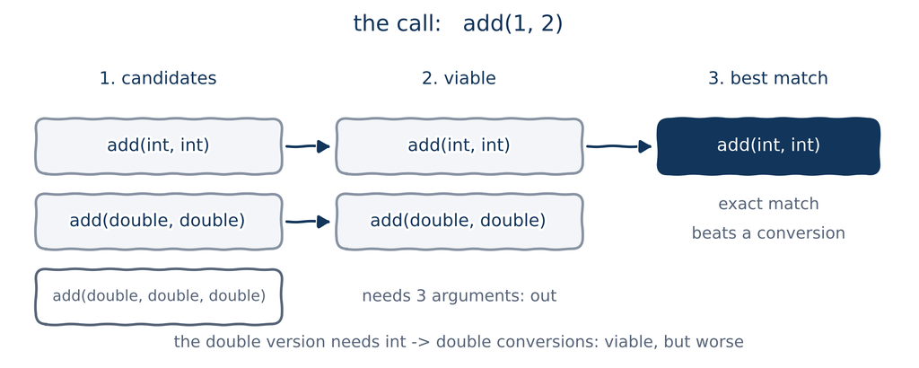

1. **Candidates:** every function with that name.
2. **Viable functions:** those with the right number of parameters, where each argument can be converted to the parameter type.
3. **Best match:** an exact match beats a promotion, which beats a conversion. If one function is strictly better than the rest, it’s called.

## 3.2 Ambiguous matches

If two overloads are *equally* good, the compiler refuses to guess:

```
ambiguous_match.cpp
```

```cpp
#include <iostream>

void print(int x) { std::cout << "int " << x << '\n'; }
void print(double x) { std::cout << "double " << x << '\n'; }

int main() {
    print(5);   // exact match: print(int)
    print(5.0); // exact match: print(double)
    print(5L);  // a long: converts to int AND to double. Which?
    return 0;
}
```

```
error: call of overloaded 'print(long int)' is ambiguous
```

`5L` is a `long`. Converting it to `int` and converting it to `double` are equally good, so neither wins. The fix: pass an argument of the type you mean, like `5` or `5.0`.

## 3.3 Calls that make no sense

```
print_int_surprise.cpp
```

```cpp
#include <iostream>

void print_int(int x) { std::cout << x << '\n'; }

int main() {
    print_int(5);    // prints 5
    print_int('a');  // prints 97: does this make sense?
    print_int(true); // prints 1: does this make sense?
    return 0;
}
```

```
5
97
1
```

A `char` and a `bool` both convert to `int` silently: `'a'` is stored as the number 97. Suppose that printing a character or a Boolean as a number makes no sense for us. Can we forbid it?

## 3.4 Deleting a function with `= delete`

```
delete_function.cpp
```

```cpp
#include <iostream>

void print_int(int x) { std::cout << x << '\n'; }

void print_int(char) = delete; // calling these is now an error
void print_int(bool) = delete;

int main() {
    print_int(97);  // fine
    print_int('a'); // error: use of deleted function
    return 0;
}
```

```
error: use of deleted function 'void print_int(char)'
```

- `= delete` declares an overload that **must not be called**. Overload resolution still picks it for a `char` argument, and then the compiler reports an error.
- Careful: `print_int(5.0)` is now an error too, because a `double` converts equally well to `int`, `char` and `bool`, so the call is ambiguous.

# 4 Default arguments

## 4.1 Default arguments

A **default argument** is a value a parameter gets when the caller doesn’t supply one.

```
default_argument.cpp
```

```cpp
#include <iostream>

void print(int x, int y = 4) { // 4 is the default argument
    std::cout << "x: " << x << ", y: " << y << '\n';
}

int main() {
    print(1, 2); // y uses the argument we give: 2
    print(3);    // y uses the default: same as print(3, 4)
    return 0;
}
```

```
x: 1, y: 2
x: 3, y: 4
```

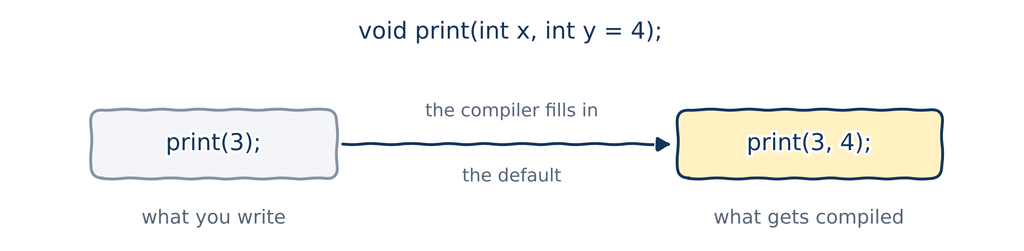

## 4.2 Several default arguments

```
multiple_default_arguments.cpp
```

```cpp
#include <iostream>

void print_numbers(int x = 10, int y = 20, int z = 30) {
    std::cout << x << ' ' << y << ' ' << z << '\n';
}

int main() {
    print_numbers(1, 2, 3); // no defaults used
    print_numbers(1, 2);    // z defaulted
    print_numbers(1);       // y and z defaulted
    print_numbers();        // all three defaulted
    return 0;
}
```

```
1 2 3
1 2 30
1 20 30
10 20 30
```

Arguments are matched to parameters from the **left**, and the defaults fill in the rest from the right.

## 4.3 The rules (and the reasons)

C++ has no syntax like `print_numbers( , , 3)`. Everything else follows from that:

- **You can’t skip an argument.** To give `z` a value, you must also give `x` and `y`.
- **Defaults must come last.** Once a parameter has a default, every parameter to its right needs one too:

  ```cpp
  void print(int x = 10, int y); // error: y needs a default as well
  ```

- **Put the parameter callers most often change first** among the defaulted ones.

**NoteComing from Python**

Python lets you name arguments in the call: `print_numbers(z=3)`. C++ has no named arguments, so the order of parameters matters much more.

## 4.4 Give the default once…

A function with a forward declaration can have its default in the declaration *or* in the definition, but **not both**:

```
default_argument_twice.cpp
```

```cpp
#include <iostream>

void print(int x, int y = 4); // forward declaration with default

void print(int x, int y = 4) { // error: default given again
    std::cout << "x: " << x << ", y: " << y << '\n';
}

int main() {
    print(3);
    return 0;
}
```

```
error: default argument given for parameter 2 of 'void print(int, int)'
```

## 4.5 …and before it’s used

The compiler reads top to bottom (Chapter 02!), so it must see the default before the call:

```
default_argument_too_late.cpp
```

```cpp
#include <iostream>

void print(int x, int y); // forward declaration: no default here

int main() {
    print(3); // error: the compiler doesn't know about the default yet
    return 0;
}

void print(int x, int y = 4) {
    std::cout << "x: " << x << ", y: " << y << '\n';
}
```

```
error: too few arguments to function 'void print(int, int)'
```

## 4.6 Where the default should go

Put the default in the **forward declaration**:

```
forward_declaration_default_arguments.cpp
```

```cpp
#include <iostream>

void print(int x, int y = 4); // the default goes here...

int main() {
    print(3);
    return 0;
}

void print(int x, int y) { // ...and not here
    std::cout << "x: " << x << ", y: " << y << '\n';
}
```

```
x: 3, y: 4
```

**TipBest practice**

Default in the forward declaration if there is one (especially in a header); otherwise in the definition.

## 4.7 With a header file

```
print.h
```

```cpp
#ifndef PRINT_H
#define PRINT_H

void print(int x, int y = 4); // default

#endif
```

```
main.cpp
```

```cpp
#include "print.h" // + its default

int main() {
    print(5); // print(5, 4)
    return 0;
}
```

```
print.cpp
```

```cpp
#include "print.h"
#include <iostream>

void print(int x, int y) { // no default repeated here
    std::cout << "x: " << x << ", y: " << y << '\n';
}
```

```
$ g++ -std=c++20 -Wall main.cpp print.cpp -o program
$ ./program
x: 5, y: 4
```

## 4.8 Default arguments and overloading

Functions with default arguments can be overloaded:

```
default_argument_overloaded.cpp
```

```cpp
#include <iostream>
#include <string>

void print(std::string s) { std::cout << s << '\n'; }
void print(char c = '*') { std::cout << c << '\n'; }

int main() {
    print("Hello, world"); // print(std::string)
    print('a');            // print(char)
    print();               // print(char), using the default '*'
    return 0;
}
```

```
Hello, world
a
*
```

## 4.9 Watch out: defaults can make calls ambiguous

A default value is **not** part of the signature, so these are two different overloads. But a call can still match both:

```
default_argument_ambiguous.cpp
```

```cpp
#include <iostream>

void print(int x) { std::cout << x << '\n'; }
void print(int x, int y = 10) { std::cout << x << ' ' << y << '\n'; }

int main() {
    print(1, 2); // fine: only print(int, int) takes two arguments
    print(1);    // error: print(int) or print(int, int = 10)?
    return 0;
}
```

```
error: call of overloaded 'print(int)' is ambiguous
```

# 5 Wrapping up

## 5.1 Summary

- **Overloading:** several functions can share a name if their **signatures** (name, number and types of parameters) differ. The return type doesn’t count.
- **Overload resolution:** the compiler picks the best match; an exact match beats a conversion. If two overloads tie, the call is **ambiguous** and won’t compile.
- `= delete` forbids particular calls.
- **Default arguments** fill in parameters the caller leaves out. Defaults must be the rightmost parameters, and can’t be skipped.
- Give a default **once**, in the forward declaration (header) if there is one, and before it’s used.
- Defaults are not part of the signature, so they can make calls ambiguous.

## 5.2 Keep learning

Explore these on your own, with Google Gemini in Guided Learning mode or on learncpp.com:

1. [Function overload resolution and ambiguous matches](https://www.learncpp.com/cpp-tutorial/function-overload-resolution-and-ambiguous-matches/). The exact ranking rules are long; try asking Gemini: *“Please teach me function overload resolution and ambiguous matches in C++.”*
2. [Implicit type conversion](https://www.learncpp.com/cpp-tutorial/implicit-type-conversion/), and the difference between promotions and conversions
3. [Type aliases](https://www.learncpp.com/cpp-tutorial/typedefs-and-type-aliases/)

**Next up, Chapter 06:** function templates. Overloading means writing every version by hand. What if the compiler could write them for us?